# Pied Flycatchers 1: Initial Models

Simon Bonner

2021-11-22

As a first example of the functions in this package we will fit a model to the pied flycatcher data. We will start by fitting a model with fixed effects on the mean and dispersion components. Specifically, we will model the load returned on each trip by the adult flycatchers a independent normal random variables with mean given by a linear combination of the logarithm of the inter-visit interval (IVI), the brood size manipulation (broodsize), and the adult’s sex, and standard deviation given by a linear combination of broodsize and sex, on the log scale. We will then incorporate individual random effects into this model.

# Library

First you have to load the package:

```r
## Load package
library(dalmatian)
```

# Raw data

The raw data for this example is provided in the package and can be accessed with:

```r
## Load pied flycatcher data
data(pied_flycatchers_1)
```

This data contains records on 5795 different food deliveries recorded during the pied flycatcher experiment. The response variable, `load`, records the load rounded to the nearest .1 gram. We want to model the logarithm of the load, and we also want to account for the rounding. To do this we will create two new variables in the data frame, `lower` and `upper`, which bound the logarithm of the true load. Not that we add .001 when the observed value is zero to avoid problems with the logarithm.

```r
## Create variables bounding the true load
pfdata$lower=ifelse(pfdata$load==0,log(.001),log(pfdata$load-.049))
pfdata$upper=log(pfdata$load+.05)
```

# Model 1: Fixed Effects

Our initial model for the logarithm of the load returned on the $j$th trip by adult $i$ will be $N(\mu_{ij},\sigma_{ij}^2)$ where:
$$\mu=\beta_0 + \beta_1 \mathrm{log(IVI)}_{ij} + \beta_2 \mathrm{broodsize}_i + \beta_3 \mathrm{sex}_i$$
and
$$\log(\sigma_{ij}^2)=\psi_0 + \psi_1 \mathrm{broodsize}_i + \psi_2\mathrm{sex}_i.$$
In the framework of generalized linear models, the variance, $\sigma^2_i$, is equal to the dispersion parameter, which we denote generically with $\phi$. Hence, the model can then be written as: $Y_{ij} \sim N(\mu_{ij},\phi_{ij})$ where:
$$\mu=\beta_0 + \beta_1 \mathrm{log(IVI)}_{ij} + \beta_2 \mathrm{broodsize}_i + \beta_3 \mathrm{sex}_i$$
and
$$\log(\phi_{ij})=\psi_0 + \psi_1 \mathrm{broodsize}_i + \psi_2\mathrm{sex}_i.$$

## Model

The components of the model for the pied flycatcher data specified above would be generated with:

```r
## Mean model
mymean <- list(fixed=list(name="alpha",
                          formula=~ log(IVI) + broodsize + sex,
                          priors=list(c("dnorm",0,.001))))

## Dispersion model
mydisp <- list(fixed=list(name="psi",
                          formula=~broodsize + sex,
                          priors=list(c("dnorm",0,.001))),
               link="log")
```

These two objects will now be used to generate the JAGS code, data, and initial values for running the model.

## Running the Model with dalmatian

The primary function in the package `dalmatian` automates the creation of the `JAGS` code, data, and initial values and then passes these to `JAGS` via the functions in the `rjags` package. The `dalmatian` function takes requires several arguments including the data frame for the analysis, the model objects created above, and the name of the `JAGS` model file. It also requires two lists containing named arguments for the functions `jags.model` and `coda.samples` from the `rjags` package. Descriptions of the arguments for these two functions are available in their own help pages. Any arguments that are not specified in these lists will take the default values given by `rjags`. The two exceptions are the `file` argument of `jags.model` and the `n.iter` argument of `coda.samples` which do not have default values and must be specified. The number of parallel chains will be taken from the `jags.model` list. If this value is not specified then three chains will be run in order that convergence diagnostics can be computed. Note that the chains have been run for a relatively small number of iterations and heavily subsampled to satisfy the size requirements for packages on . Neither of these is recommended in practice.

```r
## Set working directory
## By default uses a system temp directory. You probably want to change this.
workingDir <- tempdir()

## Define list of arguments for jags.model()
jm.args <- list(file=file.path(workingDir,"pied_flycatcher_1_jags.R"),n.adapt=1000)

## Define list of arguments for coda.samples()
cs.args <- list(n.iter=5000,thin=20)

## Run the model using dalmatian
pfmcmc1 <- dalmatian(df=pfdata,
                     mean.model=mymean,
                     dispersion.model=mydisp,
                     jags.model.args=jm.args,
                     coda.samples.args=cs.args,
                     rounding=TRUE,
                     lower="lower",
                     upper="upper",
                     residuals = FALSE,
                     debug=FALSE)
}
```

## Results

The function `dalmatian` returns list containing three objects: 1. `jags.model.args` The full list of arguments passed to `jags.model`. This includes the variables in the input list along with the name of the model file, the formatted data, and the initial values. 2. `coda.samples.args` The full list of arguments passed to `coda.samples`. This includes the variables in the input list along with the complete object returned by `jags.model.args` and the character vector including the names of the monitored parameters. 3. `coda` An object of class `mcmc.list` and length `n.chains` containing the samples generated by `JAGS`.

## Results

Inference is based on the output from the MCMC chain which is stored in the `coda` object. Summaries of the MCMC sampler and the posterior distribution can be constructed from `coda` with a variety of tools designed to work with objects of the `mcmc.list` class. For example, we can use the tools in the package `coda` to generate traceplots, density plots and histograms, numerical summaries of the posterior, and convergence diagnostics. The `ggmcmc` package can also be used to create fancier looking traceplots, density plots, and plots summarizing the posterior distribution in terms of posterior means and quantiles (credible intervals). However, several wrapper functions exist within the package to automate some of these tasks.

The first thing we should do is to check the convergence of the chains. Summary statistics computed from the output in `coda` are only valid if the chain has converged and is sampling from the correct distribution. The wrapper function `convergence()` applies three of the convergence diagnostics from the `coda` package.

```r
## Compute convergence diagnostics
pfconvergence1 <- convergence(pfmcmc1)
```

```r
## Gelman-Rubin diagnostics
pfconvergence1$gelman
```

```
## Potential scale reduction factors:
##
##                          Point est. Upper C.I.
## alpha.(Intercept)             1.003      1.015
## alpha.log(IVI)                1.004      1.016
## alpha.broodsizeIncreased      1.005      1.006
## alpha.sexMale                 0.999      1.000
## psi.(Intercept)               0.999      0.999
## psi.broodsizeIncreased        1.002      1.009
## psi.sexMale                   1.003      1.014
```

```r
## Raftery diagnostics
pfconvergence1$raftery
```

```
##
## Quantile (q) = 0.025
## Accuracy (r) = +/- 0.005
## Probability (s) = 0.95
##
## You need a sample size of at least 3746 with these values of q, r and s
```

```r
## Effective sample size
pfconvergence1$effectiveSize
```

```
##        alpha.(Intercept)           alpha.log(IVI) alpha.broodsizeIncreased
##                 777.2150                 789.0462                 786.6472
##            alpha.sexMale          psi.(Intercept)   psi.broodsizeIncreased
##                 846.6271                 518.5562                 640.6306
##              psi.sexMale
##                 663.3225
```

Details of these measures can be found in the help files of the `coda` package. Not surprisingly, these all suggest that the chains need to be run for longer.

```r
## Generate traceplots
pfraceplots1 <- traceplots(pfmcmc1,show=FALSE,nthin=20)
```

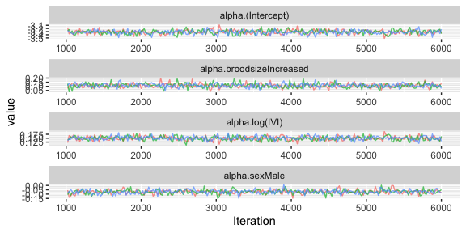

```r
## Fixed effects for mean
pftraceplots1$meanFixed
```

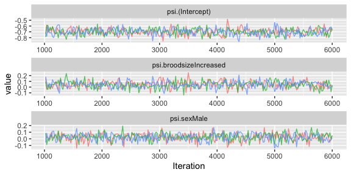

```r
## Fixed effects for dispersion
pftraceplots1$dispersionFixed
```

Numerical summaries of the posterior distribution computed from the output in `coda` can be obtained with the summary function.

```r
## Compute numerical summaries
pfsummary1 <- summary(pfmcmc1)
```

```r
## Print numerical summaries
pfsummary1
```

```
##
## Iterations = 1020:6000
## Thinning interval = 20
## Number of chains = 3
## Sample size per chain = 250
##
## Posterior Summary Statistics for Each Model Component
##
## Mean Model: Fixed Effects
##                     Mean Median   SD Lower 95% Lower 50% Upper 50% Upper 95%
## (Intercept)        -3.31  -3.31 0.07     -3.45     -3.35     -3.26     -3.20
## log(IVI)            0.15   0.15 0.01      0.13      0.14      0.16      0.18
## broodsizeIncreased  0.11   0.11 0.03      0.06      0.09      0.12      0.16
## sexMale            -0.07  -0.07 0.02     -0.13     -0.09     -0.06     -0.03
##
## Dispersion Model: Fixed Effects
##                     Mean Median   SD Lower 95% Lower 50% Upper 50% Upper 95%
## (Intercept)        -0.70  -0.70 0.06     -0.81     -0.74     -0.66     -0.60
## broodsizeIncreased  0.04   0.05 0.06     -0.07      0.01      0.08      0.16
## sexMale             0.03   0.03 0.06     -0.09     -0.02      0.06      0.12
```

For each component of the model the tables provide statistics including the estimated posterior mean, median, and standard deviation and the end points of the 50% and 95% highest posterior density credible intervals. Note that these summaries are only valid if the previous diagnostics have suggested that the chain has converged and the effective sample size is large enough. Graphical summaries can also be computed with the `caterpillar` which, like `traceplots`, is a simple wrapper for the functions in the `ggmcmc` package.

```r
## Generate caterpillar
pfcaterpillar1 <- caterpillar(pfmcmc1,show = FALSE)
```

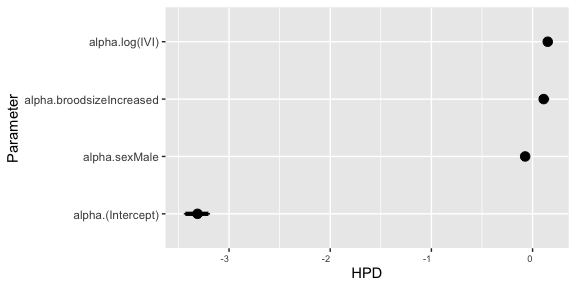

```r
## Fixed effects for mean
pfcaterpillar1$meanFixed
```

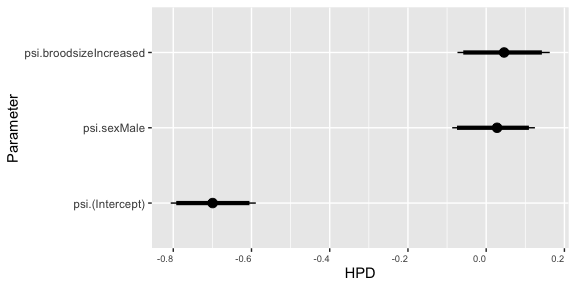

```r
## Fixed effects for dispersion
pfcaterpillar1$dispersionFixed
```

# Model 2: Random Effects

We will now consider adding individual (bird) random effects to both the fixed and random components of our model. This can be done by simply adding to the model components created above and then re-runnig the model. The new model will have mean and variance
$$\mu_{ij}=\beta_0 + \beta_1 \mathrm{log(IVI)}_{ij} + \beta_2 \mathrm{broodsize}_i + \beta_3 \mathrm{sex}_i + \epsilon_{i}}$$
and
$$\log(\phi_{ij})=\psi_0 + \psi_1 \mathrm{broodsize}_i + \psi_2\mathrm{sex}_i + \xi_j$$
where $\epsilon_i \sim N(0,\tau^2_\mu)$ and $\xi_i \sim N(0,\tau^2_\phi)$. By default the variances $\tau^2_\epsilon$ and $\tau^2_\xi$ are assigned half-$t$ prior distributions.

## Model

Instead of creating new model objects we can simply add to the old objects by creating the `random` fields. As with the fixed effects, these fields are lists which must include a basename for the random effects and formula specifying the random effects model.

```r
# Random component of mean
mymean$random <- list(name="epsilon",formula=~-1 + indidx)

# Random component of dispersion
mydisp$random <- list(name="xi",formula=~-1 + indidx)
```

## Running the Model with dalmatian

The new model can now be run using `dalmatian` in exactly the same way as above. However, we will make one change. In order to shorten the convergence time, we will base initial values on the results of the fixed effects model and then provide these as input. In particular, we will define initial values for the fixed effects of both the mean and dispersion components by taking the values from the final iterations of each of the chains run for the fixed effects model. I have also found that it is best to set initial values for the response variable, `y`, if the response is rounded. Otherwise, JAGS often fails to generate initial values that fall between the rounding limits. For convenience, we set the random effects variances equal to 1 in all three chains. Note that the chains have been run for a relatively small number of iterations and heavily subsampled to satisfy the size requirements for packages on . Neither of these is recommended in practice.

```r
## Define initial values
inits <- lapply(1:3,function(i){
                setJAGSInits(mymean,
                      mydisp,
                      y = runif(nrow(pfdata),pfdata$lower,pfdata$upper),
                      fixed.mean = tail(pfmcmc1$coda[[i]],1)[1:4],
                      fixed.dispersion = tail(pfmcmc1$coda[[i]],1)[5:7],
                      sd.mean = 1,
                      sd.dispersion=1)
  })

## Define list of arguments for jags.model()
jm.args <- list(file=file.path(workingDir,"pied_flycatcher_2_jags.R"),inits=inits,n.adapt=1000)

## Define list of arguments for coda.samples()
cs.args <- list(n.iter=5000,thin=10)

## Run the model using dalmatian
pfmcmc2 <- dalmatian(df=pfdata,
                     mean.model=mymean,
                     dispersion.model=mydisp,
                     jags.model.args=jm.args,
                     coda.samples.args=cs.args,
                     rounding=TRUE,
                     lower="lower",
                     upper="upper",
                     residuals=FALSE,
                     debug=FALSE)
```

## Results

Once again, we can use the wrapper functions within the package to examine the convergence and compute summaries of the posterior distribution. Note that the chains have been thinned in creating the traceplots to reduce the size of the package.

1. Convergence diagnostics

```r
## Compute convergence diagnostics
pfconvergence2 <- convergence(pfmcmc2)
```

```r
## Gelman-Rubin diagnostics
pfconvergence2$gelman
```

```
## Potential scale reduction factors:
##
##                          Point est. Upper C.I.
## alpha.(Intercept)              1.00       1.01
## alpha.log(IVI)                 1.00       1.00
## alpha.broodsizeIncreased       1.01       1.04
## alpha.sexMale                  1.00       1.00
## psi.(Intercept)                1.01       1.02
## psi.broodsizeIncreased         1.00       1.00
## psi.sexMale                    1.01       1.02
## sd.epsilon.indidx              1.00       1.00
## sd.xi.indidx                   1.00       1.01
```

```r
## Raftery diagnostics
pfconvergence2$raftery
```

```
##
## Quantile (q) = 0.025
## Accuracy (r) = +/- 0.005
## Probability (s) = 0.95
##
## You need a sample size of at least 3746 with these values of q, r and s
```

```r
## Effective sample size
pfconvergence2$effectiveSize
```

```
##        alpha.(Intercept)           alpha.log(IVI) alpha.broodsizeIncreased
##                 992.9394                1320.7793                 663.6353
##            alpha.sexMale          psi.(Intercept)   psi.broodsizeIncreased
##                 590.6142                 407.2076                 518.9162
##              psi.sexMale        sd.epsilon.indidx             sd.xi.indidx
##                 554.5618                1407.2474                 750.2283
```

2. Traceplots

```r
## Generate traceplots
pftraceplots2 <- traceplots(pfmcmc2, show = FALSE, nthin=20)
```

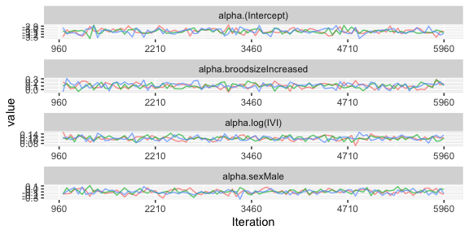

```r
## Fixed effects for mean
pftraceplots2$meanFixed
```

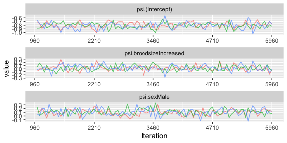

```r
## Fixed effects for dispersion
pftraceplots2$dispersionFixed
```

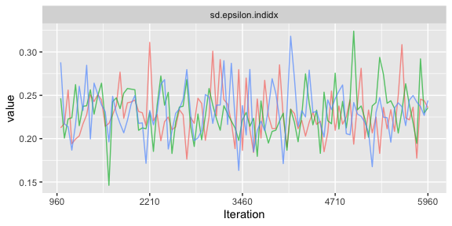

```r
## Random effects variances for mean
pftraceplots2$meanRandom
```

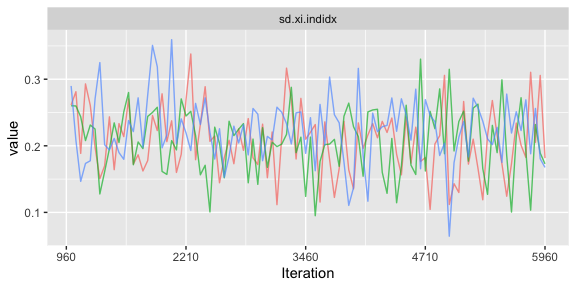

```r
## Random effects variances for dispersion
pftraceplots2$dispersionRandom
```

3. Numerical summaries

```r
## Compute numerical summaries
pfsummary2 <- summary(pfmcmc2)
```

```r
## Print numerical summaries
pfsummary2
```

```
##
## Iterations = 1010:6000
## Thinning interval = 10
## Number of chains = 3
## Sample size per chain = 500
##
## Posterior Summary Statistics for Each Model Component
##
## Mean Model: Fixed Effects
##                     Mean Median   SD Lower 95% Lower 50% Upper 50% Upper 95%
## (Intercept)        -3.09  -3.08 0.09     -3.28     -3.15     -3.03     -2.90
## log(IVI)            0.11   0.11 0.01      0.09      0.10      0.12      0.14
## broodsizeIncreased  0.11   0.11 0.07     -0.05      0.07      0.16      0.24
## sexMale            -0.10  -0.10 0.07     -0.24     -0.15     -0.05      0.04
##
## Mean Model: Random Effects
##        Mean Median   SD Lower 95% Lower 50% Upper 50% Upper 95%
## indidx 0.23   0.23 0.03      0.18      0.21      0.25      0.29
##
## Dispersion Model: Fixed Effects
##                     Mean Median   SD Lower 95% Lower 50% Upper 50% Upper 95%
## (Intercept)        -0.80  -0.80 0.08     -0.95     -0.83     -0.73     -0.64
## broodsizeIncreased  0.02   0.02 0.09     -0.15     -0.04      0.07      0.18
## sexMale             0.10   0.10 0.09     -0.07      0.04      0.15      0.28
##
## Dispersion Model: Random Effects
##        Mean Median   SD Lower 95% Lower 50% Upper 50% Upper 95%
## indidx 0.21   0.21 0.05      0.12      0.18      0.24      0.31
```

4. Graphical summaries

```r
## Generate caterpillar
pfcaterpillar2 <- caterpillar(pfmcmc2,show = FALSE)
```

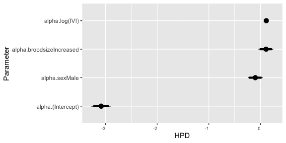

```r
## Fixed effects for mean
pfcaterpillar2$meanFixed
```

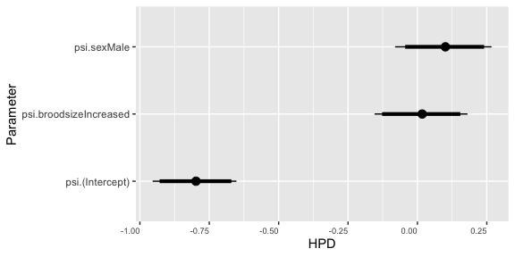

```r
## Fixed effects for dispersion
pfcaterpillar2$dispersionFixed
```